# EDUC 152. Intro to quantitative research in education: Regression analysis

Multivariate regression

# 1 Introduction

“Bivariate regression” refers to regression models with two variables, a $Y$ variable (“dependent variable” or “outcome”) and a single $X$ variable (“independent variable”)

“Multivariate regression” refers to regression models with a $Y$ variable and two or more $X$ variables

This lecture introduces multivariate regression, building on concepts we learned from lecture on bivariate regression. In particular, this lecture will focus on:

- Assumptions required to make inferences based on regression analysis
- Using multivariate regression to estimate causal effects
- Interpreting results from multivariate regresssion
  - interpreting regression output from *R*
  - interpreting results from publications that use regresion

## 1.1 Libraries, data, functions

This lecture will utilize data from two sources:

- Tennessee Student Teacher Achievement Ratio (STAR) experiment, which we have worked with before
- The Educational Longitudinal Study (ELS) of 2002

```r
# uncomment below line to remove all objects
  #rm(list = ls())

# Libraries

  # install packages if you haven't already
    #install.packages('tidyverse')
    #install.packages('labelled')
    #install.packages('haven')
    #install.packages('patchwork')
    #install.packages("RCurl") #we'll use this to calculate robust standard errors

  library(tidyverse)
  library(labelled)
  library(haven)
  #library(RCurl)
  #library(patchwork)


##########
########## TENNESSEE STAR DATA
##########

# load star data
load(file = url('https://github.com/anyone-can-cook/educ152/raw/main/data/star/star_panel_data.RData'))

#df_star_panel %>% glimpse()

# create data frame for STAR experiment, keeping only kindergarten
df_stark <- df_star_panel %>%
  # keep only kindergarten year
  filter(grade ==1) %>%
  # keep only observations with non-missing value for reading score
  filter(!is.na(read)) %>%
  # keep only observations with non-missing values for treatment assignment
  filter(!is.na(star)) %>%
  # drop observations where treatment status is regular+aide
  filter(star !=3) %>%
  # keep selected variables
  select(id,grade,star,read,gender,ethnicity,lunch,school,degree,experience) %>%
  # create a variable "treatment" that equals 1 if student receives treatment (small class) and equals 0 otherwise
  mutate(
    treatment = if_else(star==2,1,0)
  )

df_stark %>% glimpse()
```

```
#> Rows: 3,745
#> Columns: 11
#> $ id         <dbl+lbl>   943,   986,  1915,  2020,  2130,  3053,  3219,  3455,  3821,  4273,  4377,  4564,  4779,  5022,  5091,  5570,  6013,  6071,  6095,  6137,  6194,  6211,  6232,  6320,  6331,  6341,  6364,  6371,  6402,  6449,  6506,  6545,  6560,  6582,  6602,  6671,  6722,  6793,  6800,  …
#> $ grade      <dbl+lbl> 1, 1, 1, 1, 1, 1, 1, 1, 1, 1, 1, 1, 1, 1, 1, 1, 1, 1, 1, 1, 1, 1, 1, 1, 1, 1, 1, 1, 1, 1, 1, 1, 1, 1, 1, 1, 1, 1, 1, 1, 1, 1, 1, 1, 1, 1, 1, 1, 1, 1, 1, 1, 1, 1, 1, 1, 1, 1, 1, 1, 1, 1, 1, 1, 1, 1, 1, 1, 1, 1, 1, 1, 1, 1, 1, 1, 1, 1, 1, 1, 1, 1, 1, 1, 1, 1, 1, 1, 1, 1, 1, 1…
#> $ star       <dbl+lbl> 2, 2, 1, 2, 1, 1, 2, 2, 1, 2, 2, 1, 1, 2, 1, 1, 2, 1, 1, 1, 2, 1, 2, 1, 2, 2, 2, 2, 1, 2, 2, 2, 1, 2, 2, 2, 1, 2, 1, 2, 2, 2, 1, 1, 2, 1, 2, 1, 2, 2, 1, 2, 2, 2, 1, 2, 2, 2, 1, 1, 2, 1, 1, 1, 2, 2, 2, 2, 1, 2, 2, 1, 2, 2, 1, 1, 2, 1, 1, 1, 1, 1, 2, 2, 2, 1, 2, 2, 2, 1, 2, 2…
#> $ read       <int> 447, 450, 448, 447, 431, 451, 478, 455, 430, 474, 424, 439, 437, 422, 424, 431, 456, 522, 416, 419, 418, 422, 414, 450, 458, 445, 439, 476, 467, 480, 465, 407, 487, 447, 430, 480, 440, 413, 422, 442, 410, 465, 436, 436, 428, 411, 436, 472, 443, 424, 428, 440, 433, 474, 414, 411…
#> $ gender     <dbl+lbl> 2, 2, 1, 1, 1, 2, 2, 2, 1, 1, 1, 1, 2, 2, 1, 1, 1, 2, 1, 2, 1, 2, 2, 2, 2, 2, 1, 1, 2, 1, 1, 2, 2, 2, 2, 2, 2, 2, 2, 2, 2, 2, 1, 1, 1, 1, 2, 1, 1, 1, 1, 1, 1, 1, 1, 2, 2, 2, 2, 2, 2, 2, 1, 1, 1, 2, 2, 1, 1, 2, 2, 1, 1, 2, 2, 2, 1, 2, 1, 1, 2, 1, 1, 2, 2, 2, 2, 1, 2, 1, 1, 2…
#> $ ethnicity  <dbl+lbl>  1,  2,  1,  1,  1,  1,  2,  1,  1,  1,  1,  1,  2,  1,  1,  1,  1,  1,  1,  2,  1,  2,  2,  1,  1,  1,  1,  1,  1,  1,  1,  1,  2,  1,  1,  1,  1,  1,  2,  2,  2,  2,  1,  1,  1,  2,  1,  1,  1,  1,  2,  2,  2,  2,  2,  1,  2,  1,  2,  1,  1,  1,  1,  1,  1,  1,  2,  1,  1…
#> $ lunch      <dbl+lbl>  1,  1,  1,  2,  2,  1,  1,  1,  1,  1,  1,  1,  2,  1,  2,  1,  2,  1,  1,  2,  1,  2,  2,  1,  2,  1,  1,  1,  1,  1,  1,  2,  1,  1,  1,  1,  1,  1,  2,  1,  2,  1,  1,  2,  1,  2,  1,  1,  1,  2,  2,  2,  1,  2,  2,  1,  1,  1,  2,  1,  2,  1,  1,  2,  2,  2,  2,  2,  1…
#> $ school     <dbl+lbl> 3, 2, 3, 3, 3, 3, 3, 3, 3, 2, 3, 2, 2, 3, 3, 3, 4, 4, 3, 1, 3, 3, 3, 3, 3, 4, 4, 4, 3, 2, 2, 3, 1, 2, 3, 2, 3, 3, 2, 2, 1, 1, 3, 3, 2, 1, 2, 3, 3, 3, 1, 1, 1, 2, 3, 3, 2, 3, 2, 3, 4, 3, 3, 2, 3, 2, 1, 4, 3, 2, 4, 3, 3, 3, 3, 3, 3, 3, 3, 1, 3, 1, 3, 3, 3, 2, 1, 1, 4, 2, 3, 3…
#> $ degree     <dbl+lbl> 1, 1, 1, 1, 1, 1, 1, 1, 2, 1, 1, 2, 1, 2, 1, 2, 2, 1, 2, 1, 1, 2, 1, 1, 1, 2, 2, 4, 2, 1, 2, 1, 1, 2, 2, 2, 2, 2, 1, 1, 1, 1, 1, 2, 1, 1, 2, 1, 4, 1, 1, 1, 2, 1, 2, 1, 1, 1, 1, 1, 2, 1, 2, 1, 1, 1, 1, 2, 1, 1, 2, 1, 1, 1, 2, 2, 1, 1, 1, 1, 2, 1, 1, 2, 3, 1, 1, 1, 1, 4, 2, 2…
#> $ experience <int> 7, 21, 16, 5, 8, 3, 11, 10, 13, 0, 6, 13, 1, 8, 13, 13, 14, 8, 13, 0, 8, 15, 8, 10, 4, 7, 17, 12, 4, 0, 18, 4, 12, 14, 13, 14, 5, 5, 1, 5, 2, 2, 11, 13, 5, 0, 4, 5, 8, 2, 11, 14, 13, 3, 15, 20, 11, 20, 6, 11, 12, 6, 12, 18, 2, 11, 1, 17, 0, 13, 17, 20, 4, 15, 6, 10, 4, 16, 8, 6…
#> $ treatment  <dbl> 1, 1, 0, 1, 0, 0, 1, 1, 0, 1, 1, 0, 0, 1, 0, 0, 1, 0, 0, 0, 1, 0, 1, 0, 1, 1, 1, 1, 0, 1, 1, 1, 0, 1, 1, 1, 0, 1, 0, 1, 1, 1, 0, 0, 1, 0, 1, 0, 1, 1, 0, 1, 1, 1, 0, 1, 1, 1, 0, 0, 1, 0, 0, 0, 1, 1, 1, 1, 0, 1, 1, 0, 1, 1, 0, 0, 1, 0, 0, 0, 0, 0, 1, 1, 1, 0, 1, 1, 1, 0, 1, 1, 0,…
```

```r
rm(df_star_panel) # comment this line out if you want to keep data frame df_star_panel



##########
########## ELS:2002 data
##########

# RUN SCRIPT THAT CREATES STUDENT-LEVEL DATA FRAME CONTAINING ALL VARIABLES AND CREATES DATA FRAME WITH A SUBSET OF VARIABLES

  #NOTE: this script will take 30 seconds to a minute to run because loading a dataset w/ about 16,000 observations and 4,000 variables from a website

  #source(file = url('https://github.com/anyone-can-cook/educ152/raw/main/scripts/els/read_els_by_pets.R'))
    source(file = file.path('.','..','..','scripts','els','read_els_by_pets.R'))
      #list.files(path = file.path('.','..','..','scripts','els'))

# Create a dataframe df_els_stu_fac that has categorical variables as factor class variables rather than labelled class variables
  df_els_stu_fac <- as_factor(df_els_stu, only_labelled = TRUE)
  # convert continuous variables we know we want numeric back to numeric
  for (v in c('bytxmstd','bytxrstd','f1txmstd','f3stloanamt','f3stloanpay','f3ern2011','f3tzrectrans','f3tzreqtrans','f3tzschtotal')) {
    df_els_stu_fac[[v]] <- df_els_stu[[v]]
  }
```

## 1.2 ELS:2002 data

The Educational Longitudinal Study (ELS) of 2002, referred to as ELS:2002

- Nationally representative, longitudinal survey of US 10th graders in 2002, followed them from 2002 to 2013
- Created by the National Center for Education Statistics, a branch of the U.S. Department of Education
- [LINK](https://nces.ed.gov/surveys/els2002/) to ELS:2002 website
- [LINK](https://nces.ed.gov/OnlineCodebook) to the NCES “Online Codebook” website, which contains “public-use” versions of ELS datasets and detailed information about all variables
  - variables that could potentially be used to identify ELS survey respondents are “suppressed” from public-use datasets
  - these variables are present in “restricted” versions of ELS datasets

ELS datasets we created

- student-level data frame `df_els_stu_all` has all variables (about 4,000) and all observations (about 16,200 observations); one observation for each student
- student-level data frame `df_els_stu` has a subset of variables and a subset of observations
  - sample is respondents who filled completed all waves of the survey; who attended postsecondary education at some point by 2012; and some other minor sample criteria around observations not being missing for certain variables
- for both `df_els_stu_all` and `df_els_stu`, most categorical variables are `labelled` class variables
- student-level data frame `df_els_stu_fac` is exact same as `df_els_stu` except categorical variables are `factor` class; categorical variables must be factor class when running regression models

In the coming weeks, we want your help in identifying variables of interest and populations/samples of interest!

Investigate `df_els_stu` (output not shown)

Investigate `df_els_stu_fac` (output not shown)

Can use the `lookfor()` function from the `labelled` package to query which variables and variable labels contain certain words

- syntax (with defaults):
  - `look_for(data, ..., labels = TRUE, ignore.case = TRUE, details = TRUE)`
  - where argument `...` contains “strings” (e.g., words) you are looking for, enclosed in quotation marks
- example syntax, looking for variable names and variable labels that contain the word “internship”
  - `lookfor(data=df_els_stu_all, 'internship',labels = TRUE, ignore.case = TRUE, details = TRUE)`

useful to use `lookfor()` to query the dataset `df_els_stu_all` because this dataset has so many variables (more than 4,000)

```r
# query data frame df_els_stu_all
  lookfor(data=df_els_stu_all, 'internship',labels = TRUE, ignore.case = TRUE, details = TRUE)
```

```
#> # A tibble: 6 x 13
#>     pos variable label                                                                            col_type class        type   levels       value_labels na_values    na_range     unique_values  n_na range
#>   <int> <chr>    <chr>                                                                            <chr>    <named list> <chr>  <named list> <named list> <named list> <named list>         <int> <int> <named list>
#> 1   388 f1r51_c  Units in executive internship                                                    dbl+lbl  <chr [3]>    double <NULL>       <dbl [1]>    <NULL>       <NULL>                   1     0 <dbl+lbl [2]>
#> 2  1544 bys71b   Participated in internship                                                       dbl+lbl  <chr [3]>    double <NULL>       <dbl [6]>    <NULL>       <NULL>                   6     0 <dbl+lbl [2]>
#> 3  2399 f2c25a   Held internship or co-op job while enrolled in 2004-2005 school year             dbl+lbl  <chr [3]>    double <NULL>       <dbl [7]>    <NULL>       <NULL>                   7     0 <dbl+lbl [2]>
#> 4  2408 f2c30a   Held internship or co-op job while enrolled in 2005-2006 school year             dbl+lbl  <chr [3]>    double <NULL>       <dbl [7]>    <NULL>       <NULL>                   7     0 <dbl+lbl [2]>
#> 5  2506 f3a14a   High-impact PS activities:  Internship/co-op/field experience/student teaching/c dbl+lbl  <chr [3]>    double <NULL>       <dbl [7]>    <NULL>       <NULL>                   7     0 <dbl+lbl [2]>
#> 6  3348 bya18b   Internships offered to 10th-graders                                              dbl+lbl  <chr [3]>    double <NULL>       <dbl [6]>    <NULL>       <NULL>                   6     0 <dbl+lbl [2]>
```

```r
# query data frame df_els_stu
  lookfor(data=df_els_stu, 'debt',labels = TRUE, ignore.case = TRUE, details = TRUE)
```

```
#> # A tibble: 0 x 0
```

```r
  lookfor(data=df_els_stu, 'loan',labels = TRUE, ignore.case = TRUE, details = TRUE)
```

```
#> # A tibble: 4 x 13
#>     pos variable    label                                                                    col_type class        type   levels       value_labels na_values    na_range     unique_values  n_na range
#>   <int> <chr>       <chr>                                                                    <chr>    <named list> <chr>  <named list> <named list> <named list> <named list>         <int> <int> <named list>
#> 1    85 f3stloanamt Total amount borrowed in student loans                                   dbl+lbl  <chr [3]>    double <NULL>       <dbl [3]>    <NULL>       <NULL>                  58     0 <dbl+lbl [2]>
#> 2    86 f3stloanevr Whether R took out any student/PSE loans                                 dbl+lbl  <chr [3]>    double <NULL>       <dbl [6]>    <NULL>       <NULL>                   2     0 <dbl+lbl [2]>
#> 3    87 f3stloanpay Amount currently paid monthly toward student loan balance                dbl+lbl  <chr [3]>    double <NULL>       <dbl [3]>    <NULL>       <NULL>                  41     0 <dbl+lbl [2]>
#> 4    89 f3totloan   total loans taken out to pay for postsecondary education as of f3 (2013) dbl      <chr [1]>    double <NULL>       <NULL>       <NULL>       <NULL>                  58     0 <dbl [2]>
```

## 1.3 Example research questions

For the multivariate regression lecture, we will focus on using multivariate regression to answer *causal* research questions that follow the form “what is the effect of $X$ on $Y$?”

We will answer one research question that uses experimental data from the Tennessee STAR Experiment and also research questions that use observational data from ELS:2002

1. [experimental design] What is the effect of being in a small class size ($X_i=1$) vs. regular class size ($X_i=0$) on reading achievement score ($Y_i$) for kindergarten students?
   - Using data from the Tennessee Student Teacher Achievement Ratio (STAR) experiment
   - Kindergarten students randomly assigned to “small” [treatment] vs. “regular” [control] class size based on flip of a coin
   - [LINK](https://dataverse.harvard.edu/dataset.xhtml?persistentId=hdl:1902.1/10766) to information and data on the Tennessee STAR project
   - $X$ var is `treatment`; $Y$ var is `read`

```r
df_stark %>% group_by(treatment) %>% summarize(
  mean_read = mean(read, na.rm = TRUE),
)
```

```
#> # A tibble: 2 x 2
#>   treatment mean_read
#>       <dbl>     <dbl>
#> 1         0      435.
#> 2         1      441.
```

2. [observational design, categorical $X$] What is the effect of having an internship or co-op job ($X$) (in 2005-06) on 2011 earnings ($Y$)? [for students who were enrolled in postsecondary education in 2005-06]
   - $Y$ is `f3ern2011`
   - $X$ is `f2intern0506` (this would be sophomore year for students who graduated HS in spring 2004 and immediately entered postsecondary education)
     - `f2intern0506==0`: no co-op/internship
   - sample: `f2enroll0506=='yes'`

```r
df_els_stu_fac %>% filter(f2enroll0506=='yes') %>%
  group_by(f2intern0506) %>% summarize(
  mean_earn = mean(f3ern2011, na.rm = TRUE),
  n_nonmissing = sum(!is.na(f3ern2011))
)
```

```
#> # A tibble: 3 x 3
#>   f2intern0506 mean_earn n_nonmissing
#>   <fct>            <dbl>        <int>
#> 1 no              28764.         6858
#> 2 yes             33863.          450
#> 3 <NA>            34000            11
```

3. [observational design, categorical $X$] What is the effect of field of study ($X$) on earnings ($Y$)? [for respondents not currently enrolled in postsecondary education]
   - answer the RQ separately for: certificate degrees; associate’s degrees; for bachelor’s degrees?
   - $Y$ is `f3ern2011`
   - for certificate degrees: $X$ is `f3tzcrt1cip2`
   - for associate’s degrees: $X$ is `f3tzasc1cip2`
   - for bachelor’s degrees: $X$ is `f3tzbch1cip2`

```r
# certificate degrees
df_els_stu_fac %>% filter(!(f3tzcrt1cip2 %in% c('Missing','Item legitimate skip/NA')), f3a01d=='No') %>%
  group_by(f3tzcrt1cip2) %>% summarize(
  mean_earn = mean(f3ern2011, na.rm = TRUE),
  n_nonmissing = sum(!is.na(f3ern2011))
)
```

```
#> # A tibble: 5 x 3
#>   f3tzcrt1cip2                             mean_earn n_nonmissing
#>   <fct>                                        <dbl>        <int>
#> 1 Personal and culinary services              20797.           86
#> 2 Mechanic/repair technologies/technicians    31174.           53
#> 3 Health/related clinical sciences            20842.          241
#> 4 Business/management/marketing/related       29976.           21
#> 5 Other                                       31565.          108
```

```r
# associates degreees
df_els_stu_fac %>% filter(!(f3tzasc1cip2 %in% c('Missing','Item legitimate skip/NA')), f3a01d=='No') %>%
  group_by(f3tzasc1cip2) %>% summarize(
  mean_earn = mean(f3ern2011, na.rm = TRUE),
  n_nonmissing = sum(!is.na(f3ern2011))
)
```

```
#> # A tibble: 11 x 3
#>    f3tzasc1cip2                             mean_earn n_nonmissing
#>    <fct>                                        <dbl>        <int>
#>  1 Computer/information science/support        29923.           26
#>  2 Personal and culinary services              26161.           31
#>  3 Education                                   16517.           30
#>  4 Engineering technologies/technicians        29593.           28
#>  5 Liberal arts/sci/gen studies/humanities     24622.          218
#>  6 Security and protective services            27756.           39
#>  7 Mechanic/repair technologies/technicians    38006.           35
#>  8 Visual and performing arts                  19403.           31
#>  9 Health/related clinical sciences            29003.          151
#> 10 Business/management/marketing/related       33240.          107
#> 11 Other                                       28303.           88
```

```r
# bachelor's degreees
df_els_stu_fac %>% filter(!(f3tzbch1cip2 %in% c('Missing','Item legitimate skip/NA')), f3a01d=='No') %>%
  group_by(f3tzbch1cip2) %>% summarize(
  mean_earn = mean(f3ern2011, na.rm = TRUE),
  n_nonmissing = sum(!is.na(f3ern2011))
) %>% print(n=30)
```

```
#> # A tibble: 27 x 3
#>    f3tzbch1cip2                             mean_earn n_nonmissing
#>    <fct>                                        <dbl>        <int>
#>  1 Agriculture/operations/related sciences     30788.           33
#>  2 Natural resources and conservation          27828.           29
#>  3 Architecture and related services           30478.           23
#>  4 Communication, journalism, related          31085.          240
#>  5 Computer/information science/support        44458.           60
#>  6 Education                                   29519.          185
#>  7 Engineering                                 51410.          156
#>  8 Engineering technologies/technicians        44267.           36
#>  9 Foreign languages/literature/linguistics    32247.           45
#> 10 Family/consumer sciences/human sciences     26189.           53
#> 11 English language and literature/letters     24202.           96
#> 12 Liberal arts/sci/gen studies/humanities     29733.           45
#> 13 Biological and biomedical sciences          20472.          137
#> 14 Mathematics and statistics                  38931.           36
#> 15 Multi/interdisciplinary studies             25251.           66
#> 16 Parks/recreation/leisure/fitness studies    26736.          106
#> 17 Philosophy and religious studies            23977.           22
#> 18 Physical sciences                           33311.           37
#> 19 Psychology                                  25680.          176
#> 20 Security and protective services            36736.           70
#> 21 Public administration/social service        26639.           61
#> 22 Social sciences                             32916.          318
#> 23 Visual and performing arts                  24297.          215
#> 24 Health/related clinical sciences            42889.          264
#> 25 Business/management/marketing/related       41515.          751
#> 26 History                                     25771.           75
#> 27 Other                                       29107.           61
```

4. [observational design, continuous $X$] What is the effect of amount borrowed in student loans ($X$) on earnings ($Y$) for respondents not currently enrolled in postsecondary education
   - $X$ var is `f3totloan`; $Y$ var is `f3ern2011`
   - sample: `f3a01d=='No'`

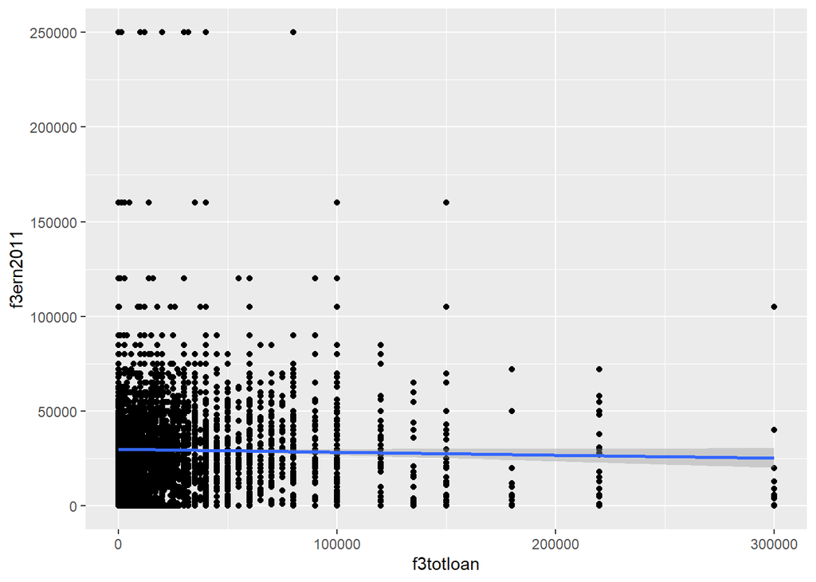

```r
df_els_stu_fac %>% filter(f3a01d=="No") %>%  ggplot(aes(x=f3totloan, y=f3ern2011)) + geom_point() + stat_smooth(method = 'lm')
```

```r
summary(lm(formula = f3ern2011 ~ f3totloan, data = df_els_stu %>% filter(f3a01d==0)))
```

```
#>
#> Call:
#> lm(formula = f3ern2011 ~ f3totloan, data = df_els_stu %>% filter(f3a01d ==
#>     0))
#>
#> Residuals:
#>    Min     1Q Median     3Q    Max
#> -29971 -16577  -3769  10351 221273
#>
#> Coefficients:
#>                 Estimate   Std. Error t value            Pr(>|t|)
#> (Intercept) 29971.343400   358.117571  83.691 <0.0000000000000002 ***
#> f3totloan      -0.015558     0.009277  -1.677              0.0936 .
#> ---
#> Signif. codes:  0 '***' 0.001 '**' 0.01 '*' 0.05 '.' 0.1 ' ' 1
#>
#> Residual standard error: 25220 on 6601 degrees of freedom
#> Multiple R-squared:  0.0004259,  Adjusted R-squared:  0.0002745
#> F-statistic: 2.813 on 1 and 6601 DF,  p-value: 0.09356
```

Why are we using test scores and earnings as dependent variables?

- Ordinary Least Squares (OLS) multivariate regression assumes continuous dependent variable; regression models with categorical dependent variables are a bit more difficult to interpret
- But in later weeks, we may introduce the “linear probability model,” which will enable us to model dichotomous (two-category) dependent variables (e.g., 0/1 did student graduate)

# 2 Intro multivariate regression

## 2.1 Multivariate regression model

**Population Regression Model**

- Same as in “simple” (bivariate) regression; we just add more regressors (i.e., independent/control variables) into our model!

Population Regression Model

- $Y_i = \beta_0 + \beta_1X_{1i} + \beta_2X_{2i} +$ … $\beta_kX_{ki} + u_i$
- Where:
  - $Y_i$ = observation i of dependent variable
  - $X_{1i}$ = observation i of the **first regressor**, $X_1$
  - $X_{2i}$ = observation i of the **second regressor**, $X_2$
  - $X_{ki}$ = observation i of the **Kth regressor**, $X_k$
  - $\beta_1$ = population average effect of Y for “change” in $X_1$
    - if $X_1$ is continuous: average effect of Y for one-unit increase/decrease in $X_1$
    - if $X_1$ is categorical: population average effect of being in the non-reference group as opposed to the reference group
  - $\beta_2$ = population average effect of Y for “change” in $X_2$
  - $\beta_k$ = population average effect of Y for “change” $X_k$
  - $\beta_0$ = average value of Y when the value of *all independent variables ($X_1, X_2 ...X_k$) are equal to zero*
  - $u_i$ = all other variables that affect the value of $Y_i$ but are not included in the model

Writing out the population linear regression model

- Important to define which specific variable (e.g., “parental income”) is associated with which $X_{ki}$ in the model
  - usually $X_{1i}$ would be your “independent variable of interest” (assuming it is a continuous variable or a two-category categorical variable)
  - but it doesn’t really matter which specific variable is associated with which $X_{ki}$ as long as you make it clear to your reader (and yourself!!!)
- You don’t need to define what $\beta_k$ means because that’s just the population regression coefficient associated with a particular variable $X_{ki}$

**Things we do in regression; all work the same in multivariate!**

1. Estimation
   - Choose estimates for $\beta_0, \beta_1, \beta_2, ... \beta_k$ by selecting those that minimize the sum of squared errors (i.e., make the best prediction of Y), yielding an OLS line
     - $\hat{Y_i} = \hat{\beta_0} + \hat{\beta_1} X_{1i} + \hat{\beta_2} X_{2i} + ... \hat{\beta_k} X_{ki}$
2. Measures of model fit (e.g., $R^2$, SER)
   - But formulas change slightly to account for “degrees of freedom”
   - Once you introduce multiple independent variables, use adjusted R-squared
   - Adjusted R-squared
     - Adjusted for the number of predictors in the model
     - Every independent variable we add to the model will increase our “normal” R-squared; but doesn’t necessarily mean it’s a better fit
     - Adjusted R squared increases only if new variable improves the model more than would be expected by chance
3. Prediction
   - Once you estimate OLS regression line, we can calculate predicted values for observations with particular values of all independent variables
     - $\hat{Y_i} = \hat{\beta_0} + \hat{\beta_1} X_{1i} + \hat{\beta_2} X_{2i} + ... \hat{\beta_k} X_{ki}$
4. Hypothesis testing and confidence intervals about $\beta_1$
   - Same as before but formulas for $\hat{\beta_1}$ and $SE(\hat{\beta_1})$ change slightly, but R calculates this for us!

## 2.2 Conditional independence assumption (CIA)

**OLS Assumption 1: Conditional Independence Assumption**

- OLS Assumption 1 (in words)
  - the independent variable $X_i$ is unrelated to the “other variables” not included in the model, $u_i$
- OLS Assumption 1 (mathematically)
  - $E(u_i|X_i)=0$; the expected value of $u_i$, given any value of $X_i$, equals zero

**Omitted variable bias**

- Omitted variable bias is bias in $\hat{\beta_1}$ due to variables being omitted from the model
- For omitted variable bias to occur, the omitted variable “Z” must satisfy two conditions
  - 1. $Z$ affects value of Y (i.e. Z is part of $u_i$)
  - 2. *and* $Z$ has a relationship with $X$

Multivariate regression helps us meet the conditional independence assumption by including variables in our model whose exclusion would result in omitted variable bias

- The modeling goal is that, after including “control variables” in our model (those that meet both conditions of omitted variable bias), “treated units” ($X_{1i}==1$ ) are on average the same as “untreated units” ($X_{1i}==0$ ) except for the value of variable $X_{1i}$

**Conditional Independence Assumption in evaluation of the Mexican American Studies (MAS) Program**

Cabrera, N. L., Milem, J. F., Jaquette, O., & Marx, R. (2014). Missing the (student achievement) forest for all the (political) trees: Empiricism and the Mexican American Studies controversy in Tucson. *American Educational Research Journal*, 51(6), 1084-1118.

- Research question
  - What is the effect of participating in Mexican American Studies program (MAS) on academic achievement (measured as score on high school exit exam)?
- $Y_i = \beta_0 + \beta_1X_{1i} + \beta_2X_{2i} + \beta_3X_{3i} + u_i$, where:
  - Y= High school exit exam score
  - X1 = 0/1 MAS participation [non-reference group]; Did not participate in MAS [reference group]
    - students can participate in MAS in 11th grade
  - X2= previous academic achievement
    - academic achievement prior to 11th grade
  - X3= socioeconomic status
- The causal inference problem:
  - we want to know the causal effect of MAS on Y
  - But we have to account for the fact that students choose to participate in MAS (self-selection bias); they were not randomly assigned to participate versus not participate in MAS!
  - Goal is to recreate “experimental conditions” by adding “control variables” to our model; after including control variables MAS participants are (in theory) the same as non-participants, except for participation in MAS
- **Conditional independence assumption**:
  - Once we include control variables, there are no longer any omitted variables, Z, that satisfy *both* of these two conditions:
    1. Z affects value of Y *and*
    2. Z has a relationship with X
- so we try to include all “control variables” that satisfy both conditions of omitted variable bias;
- If we satisfy the conditional independence assumption through control variables, then multivariate regression is just as good as randomized assignment experiment!
  - if we fail to include important control variables (because we don’t have access to them), our results suffer from omitted variable bias
  - Warning: But we often don’t have every single control variable we need, so we get as close as possible!

**Multivariate regression in Econometrics vs traditional social science statistics**

- $Y_i = \beta_0 + \beta_1X_{1i} + \beta_2X_{2i} + \beta_3X_{3i} + u_i$
- Econometrics/causal inference
  - We are only interested in estimating $\beta_1$ [the causal effect of $X_{1i}$ on Y]
  - The **primary** reason we include other variables in the model besides X1 is to eliminate omitted variable bias
  - Therefore, we include all control variables that satisfy *both* conditions of omitted variable bias
  - Once we include control variables, and no other variables satisfy both conditions, then we satisfy the conditional independence assumption and we can estimate a causal effect!
- Traditional social science statistics [most of my research!]
  - Purpose of multiple regression is to add new variable to your model (e.g., $X_3$) to see the effect of $X_3$ on Y
  - Can lead to sloppy research if we take a “throw” everything and the kitchen sink into a model and see what’s interesting!
  - We’ll read example of this kind of research:
    - Powers (2004)

“Good” vs. “bad” research

- “Good” research
  - Goal is to estimate causal effects and you are thoughtful about including control variables to minimize omitted variable bias
  - Goal is to understand correlational/associational relationship between $X$ variables and $Y$, and when interpretating results, you are careful to talk about “association” rather than “causal effect”
- “Bad” research
  - Goal is to estimate causal effects but researcher isn’t thoughtful about which control variables should be included in the model
  - Goal is to understand correlational/associational relationships but the author inteprets regression coefficients as if they represent causal relationships

## 2.3 Interpretation

Research question we will use to practice interpretation of multivariate regression, using data frame `df_els_stu_fac`:

[observational design, categorical $X$] What is the effect of having an internship or co-op job ($X$) (in 2005-06) on subsequent earnings ($Y$) (in 2011)?

_Identify a couple of “control variables” (often referred to “covariates”) to add to our model__

We want to recreate “experimental conditions” (students randomly assigned to internship)

- Our goal is: after controlling for covariates, students who participate in internships are, on average, the same as students who do not participate in internships with respect to 2011 earnings, exepct for participation in internship
- We include control variables that we think (based on logical argument, past research, descriptive stats) satisfy both conditions of omitted variable bias:
  - For omitted variable bias to occur, the omitted variable “Z” must satisfy two conditions
    - 1. $Z$ affects value of Y (i.e. Z is part of $u_i$)
    - 2. *and* $Z$ has a relationship with $X$

We’ll add one continuous control variable and two categorical control variable

```r
# reading test score
df_els_stu_fac %>% filter(f2enroll0506=='yes') %>% summarize(
  min_read = min(bytxrstd, na.rm = TRUE),
  mean_read = mean(bytxrstd, na.rm = TRUE),
  max_read = max(bytxrstd, na.rm = TRUE),
  sd_read = sd(bytxrstd, na.rm = TRUE)
)
```

```
#> # A tibble: 1 x 4
#>    min_read mean_read  max_read sd_read
#>   <dbl+lbl>     <dbl> <dbl+lbl>   <dbl>
#> 1      24.2      54.4      78.8    9.03
```

```r
# sex
df_els_stu_fac %>% filter(f2enroll0506=='yes') %>% count(f1sex)
```

```
#> # A tibble: 2 x 2
#>   f1sex      n
#>   <fct>  <int>
#> 1 Male    3225
#> 2 Female  4094
```

```r
# sex, show underlying integer values
df_els_stu_fac %>% filter(f2enroll0506=='yes') %>% count(as.integer(f1sex))
```

```
#> # A tibble: 2 x 2
#>   `as.integer(f1sex)`     n
#>                 <int> <int>
#> 1                   1  3225
#> 2                   2  4094
```

```r
# race
df_els_stu_fac %>% filter(f2enroll0506=='yes') %>% count(f1race_v2)
```

```
#> # A tibble: 6 x 2
#>   f1race_v2     n
#>   <fct>     <int>
#> 1 white      4629
#> 2 api         820
#> 3 black       768
#> 4 latinx      776
#> 5 native       35
#> 6 multi       291
```

```r
# race, show underlying integer values
df_els_stu_fac %>% filter(f2enroll0506=='yes') %>% count(as.integer(f1race_v2))
```

```
#> # A tibble: 6 x 2
#>   `as.integer(f1race_v2)`     n
#>                     <int> <int>
#> 1                       1  4629
#> 2                       2   820
#> 3                       3   768
#> 4                       4   776
#> 5                       5    35
#> 6                       6   291
```

**Review interpretation for Bivariate regression model**

- run bivariate regression

```r
intern_mod1 <- lm(formula = f3ern2011 ~ f2intern0506, data = df_els_stu_fac %>% filter(f2enroll0506=='yes'))
summary(intern_mod1)
```

```
#>
#> Call:
#> lm(formula = f3ern2011 ~ f2intern0506, data = df_els_stu_fac %>%
#>     filter(f2enroll0506 == "yes"))
#>
#> Residuals:
#>    Min     1Q Median     3Q    Max
#> -33863 -16764  -3764  11236 221236
#>
#> Coefficients:
#>                 Estimate Std. Error t value             Pr(>|t|)
#> (Intercept)      28763.9      296.7  96.937 < 0.0000000000000002 ***
#> f2intern0506yes   5099.2     1195.8   4.264            0.0000203 ***
#> ---
#> Signif. codes:  0 '***' 0.001 '**' 0.01 '*' 0.05 '.' 0.1 ' ' 1
#>
#> Residual standard error: 24570 on 7306 degrees of freedom
#>   (11 observations deleted due to missingness)
#> Multiple R-squared:  0.002483,   Adjusted R-squared:  0.002346
#> F-statistic: 18.18 on 1 and 7306 DF,  p-value: 0.00002031
```

- Population linear regression model (bivariate regression)
  - $Y_i = \beta_0 + \beta_1 X_{1i}+ u_i$, where:
    - $Y_i$: is earnings for student $i$ in 2011
    - $X_{1i}$: is a dichotomous categorical variable indicating whether student $i$ had an internship in the 2005-06 academic year
    - $u_i$ is all variables that affect $Y_i$ but were not included in our model
- OLS prediction line
  - without estimates
    - $\hat{Y_i} = \hat{\beta_0} + \hat{\beta_1}X_i$
  - with estimates
    - $\hat{Y_i} =$ 28,764 + 5,099 $\times X_i$
- Interpretation of $\hat{\beta_1}$ for categorical $X_1$
  - Generic:
    - “being [specific non-reference category] as opposed to [reference category] is, on average, associated with a $\hat{\beta_1}$ change in $Y$”
  - Specific interpretation of $\hat{\beta_1}=$ 5,099
    - having an internship as opposed to not having an internship is, on average, associated with a 5,099 dollar change in annual earnings
- Interpretation of $\hat{\beta_0}$
  - Generic:
    - $\hat{\beta_0}$ is the estimated average value of the outcome, $\hat{Y_i}$, when all independent variables $X_{1i},X_{2i},\ldots X_{ki}$ equal `0`
    - *Note*: for categorical independent variables, “equals `0`” means being the category associated with the reference group
  - Specific interpretation of $\hat{\beta_0}=$ 28,764
    - The estimated average 2011 earnings for students who did not have an internship is 28,764

**Multivariate regression**

run multivariate regression model, adding control variables `bytxrstd` (reading achievement, continuous), `f1sex` (sex, categorical), and `f1race_v2` (race, categorical) to the model

- syntax for `lm` function: `lm(formula = yvar ~ xvar1 + xvar2 + xvar3, data = data_frame_name)`

```r
intern_mod2 <- lm(formula = f3ern2011 ~ f2intern0506 + bytxrstd  + f1sex + f1race_v2, data = df_els_stu_fac %>% filter(f2enroll0506=='yes'))
summary(intern_mod2)
```

```
#>
#> Call:
#> lm(formula = f3ern2011 ~ f2intern0506 + bytxrstd + f1sex + f1race_v2,
#>     data = df_els_stu_fac %>% filter(f2enroll0506 == "yes"))
#>
#> Residuals:
#>    Min     1Q Median     3Q    Max
#> -39866 -16030  -2796  11198 225259
#>
#> Coefficients:
#>                  Estimate Std. Error t value             Pr(>|t|)
#> (Intercept)      22418.27    1911.29  11.729 < 0.0000000000000002 ***
#> f2intern0506yes   5640.81    1181.46   4.774        0.00000183704 ***
#> bytxrstd           199.98      32.96   6.067        0.00000000137 ***
#> f1sexFemale      -5925.57     571.29 -10.372 < 0.0000000000000002 ***
#> f1race_v2api     -1371.74     924.35  -1.484               0.1379
#> f1race_v2black   -4885.98     975.53  -5.009        0.00000056138 ***
#> f1race_v2latinx  -4214.37     960.21  -4.389        0.00001154844 ***
#> f1race_v2native -10133.31    4118.80  -2.460               0.0139 *
#> f1race_v2multi   -2080.70    1464.50  -1.421               0.1554
#> ---
#> Signif. codes:  0 '***' 0.001 '**' 0.01 '*' 0.05 '.' 0.1 ' ' 1
#>
#> Residual standard error: 24220 on 7299 degrees of freedom
#>   (11 observations deleted due to missingness)
#> Multiple R-squared:  0.03188,    Adjusted R-squared:  0.03082
#> F-statistic: 30.05 on 8 and 7299 DF,  p-value: < 0.00000000000000022
```

- Population linear regression model (multivariate regression)
  - $Y_i = \beta_0 + \beta_1 X_{1i}+ \beta_2 X_{2i}+ \beta_3 X_{3i}+ \beta_4 X_{4i}+ \beta_5 X_{5i}+ \beta_6 X_{6i}+ \beta_7 X_{7i}+ \beta_8 X_{8i}+ u_i$, where:
    - $Y_i$: is earnings for student $i$ in 2011
    - $X_{1i}$: is a dichotomous categorical variable indicating whether student $i$ had an internship in 2005-06
    - $X_{2i}$: (continuous) high school reading test score
    - $X_{3i}$: (dichotomous) student $i$ identifies as female
    - $X_{4i}$: (dichotomous) student $i$ identifies as Asian or Pacific Islander (API)
    - $X_{5i}$: (dichotomous) student $i$ identifies as Black
    - $X_{6i}$: (dichotomous) student $i$ identifies as Latinx
    - $X_{7i}$: (dichotomous) student $i$ identifies as Native American
    - $X_{8i}$: (dichotomous) student $i$ identifies as two or more races
    - $u_i$ is all variables that affect $Y_i$ but were not included in our model
- OLS prediction line
  - without estimates
    - $\hat{Y_i} = \hat{\beta_0} + \hat{\beta_1}X_i + \hat{\beta_2} X_{2i}+ \hat{\beta_3} X_{3i}+ \hat{\beta_4} X_{4i}+ \hat{\beta_5} X_{5i}+ \hat{\beta_6} X_{6i}+ \hat{\beta_7} X_{7i}+ \hat{\beta_8} X_{8i}$
  - with estimates
    - $\hat{Y_i} =$ 22,418 + 5,641 $\times X_{1i}$ + 200 $\times X_{2i}$ + -5,926 $\times X_{3i}$ + -1,372 $\times X_{4i}$ + -4,886 $\times X_{5i}$ + -4,214 $\times X_{6i}$ + -10,133 $\times X_{7i}$ + -2,081 $\times X_{8i}$

**Interpretation $\hat{\beta_k}$**

Interpretation of $\hat{\beta_k}$ from multivariate regression is almost exactly the same as interpretation from bivariate regression

Interpretation of $\hat{\beta_k}$ (for continuous variable $X_k$)

- Generic:
  - “a one-unit increase in $X_k$ is associated with a $\hat{\beta_k}$ change in Y, **holding the value of all other $X$ variables constant**”
- For high school reading test score $X_{2i}$, $\hat{\beta_2}=$ 200
  - a one-point increase in high school reading test score is associated with a 200 change in 2011 earnings, holding the value of all other $X$ variables constant

Interpretation of $\hat{\beta_k}$ (for categorical variable $X_k$)

- Generic:
  - “being [specific non-reference category] as opposed to [reference category] is, on average, associated with a $\hat{\beta_k}$ change in $Y$, **holding the of value all other $X$ variables constant**”
- For participation in internship $X_{1i}$, $\hat{\beta_1}=$ 5,641
  - having an internship as opposed to not having an internship is, on average, associated with a 5,641 dollar change in annual earnings, holding the value of all other $X$ variables constant

**What does “holding constant” mean?**

- “Holding the value of all other $X$ variables constant” means to estimate the relationship between $X_1$ (internship) and $Y$ when we we don’t allow the values of $X_2$ (high school reading test score) to vary (and we don’t allow any other $X$ variables to vary)
- In other words, we analyze the relationship between having an internship $X_1$ and earnings ($Y$) for students who have the same value for high school reading test score ($X_2$), the same value for sex ($X_3$), the same value for “identify as API” ($X_4$), etc.
- Mathematically, “holding constant” is achieved through calculus (partial derivatives)

**Relationship between “holding constant” and attempting to recreate experimental conditions**

- We use multivariate regression to try to recreate experimental conditions (students randomly assigned to participate in internships)
- In a true experiment, both students randomly assigned to an internship and students randomly assigned to not have an internship would, on average, have the same values for other variables that affect earnings $Y$ (e.g,. gender, race, parental income)
- In multivariate regression, we add “control variables” (variables that satisfy both conditions of omitted variable bias) so that we can examine the relationship between having an internship ($X_1$) and earnings ($Y$) for students who have the same value for other variables thought to affect earnings
  - Means to estimate the relationship between $X_1$ and Y when we don’t allow the value of $X_2$ to vary
  - In other words, we analyze the relationship between student teacher ration ($X_1$) and reading test scores (Y) for applicants that have the same value of percent ELL ($X_2$) [calculus: partial derivatives!]

**More practice interpreting $\hat{\beta_k}$ (for categorical $X$)**

- Population linear regression model (multivariate regression)
  - $Y_i = \beta_0 + \beta_1 X_{1i}+ \beta_2 X_{2i}+ \beta_3 X_{3i}+ \beta_4 X_{4i}+ \beta_5 X_{5i}+ \beta_6 X_{6i}+ \beta_7 X_{7i}+ \beta_8 X_{8i}+ u_i$, where:
    - $Y_i$: is earnings for student $i$ in 2011
    - $X_{1i}$: is a dichotomous categorical variable indicating whether student $i$ had an internship in 2005-06
    - $X_{2i}$: (continuous) high school reading test score
    - $X_{3i}$: (dichotomous) student $i$ identifies as female
    - $X_{4i}$: (dichotomous) student $i$ identifies as Asian or Pacific Islander (API)
    - $X_{5i}$: (dichotomous) student $i$ identifies as Black
    - $X_{6i}$: (dichotomous) student $i$ identifies as Latinx
    - $X_{7i}$: (dichotomous) student $i$ identifies as Native American
    - $X_{8i}$: (dichotomous) student $i$ identifies as two or more races
    - $u_i$ is all variables that affect $Y_i$ but were not included in our model
- OLS prediction line
  - without estimates
    - $\hat{Y_i} = \hat{\beta_0} + \hat{\beta_1}X_i + \hat{\beta_2} X_{2i}+ \hat{\beta_3} X_{3i}+ \hat{\beta_4} X_{4i}+ \hat{\beta_5} X_{5i}+ \hat{\beta_6} X_{6i}+ \hat{\beta_7} X_{7i}+ \hat{\beta_8} X_{8i}$
  - with estimates
    - $\hat{Y_i} =$ 22,418 + 5,641 $\times X_{1i}$ + 200 $\times X_{2i}$ + -5,926 $\times X_{3i}$ + -1,372 $\times X_{4i}$ + -4,886 $\times X_{5i}$ + -4,214 $\times X_{6i}$ + -10,133 $\times X_{7i}$ + -2,081 $\times X_{8i}$

Interpretation of $\hat{\beta_k}$ (for categorical variable $X_k$)

- Generic:
  - “being [specific non-reference category] as opposed to [reference category] is, on average, associated with a $\hat{\beta_k}$ change in $Y$, holding the of value all other $X$ variables constant”
  - Conceptually, we have two categorical control variables in our model; the first is sex, where the reference group is “male”; the second is race, where the reference group is “white”
- $X_{3i}$ (identifies as female); $\hat{\beta_k}=$ -5,926
  - being female as opposed to male is associated with a -5,926 change in 2011 earnings, holding the of value all other $X$ variables constant
- $X_{4i}$ (identifies as Asian or Pacific Islander (API)); $\hat{\beta_k}=$ -1,372
  - being API as opposed to white is associated with a -1,372 change in 2011 earnings, holding the of value all other $X$ variables constant
- $X_{5i}$ (identifies as Black); $\hat{\beta_k}=$ -4,886
  - being Black as opposed to wrhite is associated with a -4,886, holding the of value all other $X$ variables constant
- $X_{6i}$ (identifies as Latinx); $\hat{\beta_k}=$ -4,214
  - You do the rest!
- $X_{7i}$ (identifies as Native American); $\hat{\beta_k}=$ -10,133
- $X_{8i}$ (identifies as two or more races; $\hat{\beta_k}=$ -2,081

**Interpretation of $\hat{\beta_0}$ in multivariate regression**

- Conceptually, the same as interpretation for bivariate regression
- $\hat{\beta_0}$ is the estimated average value of the outcome, $\hat{Y_i}$, when all independent variables $X_{1i},X_{2i},\ldots X_{ki}$ equal `0`
  - *Note*: for categorical independent variables, “equals `0`” means being the category associated with the reference group
- Specific interpretation of $\hat{\beta_0}=$ 22,418
  - The estimated average 2011 earnings for white, male students who did not have an internship and who got a score of `0` on the high school reading test is 22,418

**Prediction (still works the same way!)**

- Population linear regression model (multivariate regression)
  - $Y_i = \beta_0 + \beta_1 X_{1i}+ \beta_2 X_{2i}+ \beta_3 X_{3i}+ \beta_4 X_{4i}+ \beta_5 X_{5i}+ \beta_6 X_{6i}+ \beta_7 X_{7i}+ \beta_8 X_{8i}+ u_i$, where:
    - $Y_i$: is earnings for student $i$ in 2011
    - $X_{1i}$: is a dichotomous categorical variable indicating whether student $i$ had an internship in 2005-06
    - $X_{2i}$: (continuous) high school reading test score
    - $X_{3i}$: (dichotomous) student $i$ identifies as female
    - $X_{4i}$: (dichotomous) student $i$ identifies as Asian or Pacific Islander (API)
    - $X_{5i}$: (dichotomous) student $i$ identifies as Black
    - $X_{6i}$: (dichotomous) student $i$ identifies as Latinx
    - $X_{7i}$: (dichotomous) student $i$ identifies as Native American
    - $X_{8i}$: (dichotomous) student $i$ identifies as two or more races
    - $u_i$ is all variables that affect $Y_i$ but were not included in our model
- OLS prediction line
  - without estimates
    - $\hat{Y_i} = \hat{\beta_0} + \hat{\beta_1}X_i + \hat{\beta_2} X_{2i}+ \hat{\beta_3} X_{3i}+ \hat{\beta_4} X_{4i}+ \hat{\beta_5} X_{5i}+ \hat{\beta_6} X_{6i}+ \hat{\beta_7} X_{7i}+ \hat{\beta_8} X_{8i}$
  - with estimates
    - $\hat{Y_i} =$ 22,418 + 5,641 $\times X_{1i}$ + 200 $\times X_{2i}$ + -5,926 $\times X_{3i}$ + -1,372 $\times X_{4i}$ + -4,886 $\times X_{5i}$ + -4,214 $\times X_{6i}$ + -10,133 $\times X_{7i}$ + -2,081 $\times X_{8i}$

What is the predicted 2011 earnings for a student who participated in an internship ($X_{1i}=1$), who scored 65 on the high school reading test ($X_{2i}=65$), who identifies as female ($X_{3i}=1$), and who identifies as Latinx ($X_{6i=1}$)?

- $\hat{Y_i} = \hat{\beta_0} + \hat{\beta_1}\times 1 + \hat{\beta_2} \times 65 + \hat{\beta_3} \times 1 + \hat{\beta_4} \times 0+ \hat{\beta_5} \times 0+ \hat{\beta_6} \times 1 + \hat{\beta_7} \times 0 + \hat{\beta_8} \times 0$
- $\hat{Y_i} = \hat{\beta_0} + \hat{\beta_1}\times 1 + \hat{\beta_2} \times 65 + \hat{\beta_3} \times 1 + \hat{\beta_6} \times 1$
- $\hat{Y_i} =$ 22,418 + 5,641$\times 1$ + 200$\times 65$ + -5,926$\times 1$ + -4,214$1 = $ 30,918

What is the predicted 2011 earnings for a student who participated in an internship ($X_{1i}=1$), who scored 45 on the high school reading test ($X_{2i}=65$) and who identifies as white, who identifies as male?

- $\hat{Y_i} = \hat{\beta_0} + \hat{\beta_1}\times 1 + \hat{\beta_2} \times 45 + \hat{\beta_3} \times 0 + \hat{\beta_4} \times 0+ \hat{\beta_5} \times 0+ \hat{\beta_6} \times 0 + \hat{\beta_7} \times 0 + \hat{\beta_8} \times 0$
- $\hat{Y_i} = \hat{\beta_0} + \hat{\beta_1}\times 1 + \hat{\beta_2} \times 45$
- $\hat{Y_i} =$ 22,418 + 5,641 $\times 1 +$ 200 $\times 45 =$ 37,058

# 3 Reading Empirical Regression Results

**Our first example of empirical regression results**

Powers, J. M. (2004). High-Stakes Accountability and Equity: Using Evidence From California’s Public Schools Accountability Act to Address the Issues in Williams v. State of California. *American Educational Research Journal*, 41(4), 763–795.

- RQ: What is relationship between school resource variables and school-level academic performance index (API)?
- Does not frame article as “causal inference” but Powers is doing exactly what we have learned in this lecture/class!
  - Attempts to analyze the effect of school resources (X) on the academic achievement of schools (Y) by controlling for variables that would be “systematically related” to the independent variables of interest and have an effect on the dependent variable
  - Does not have all possible controls to get to a “causal effect” equivalent to what we would estimate if the study was designed as an randomized control experiment.

**How to read a methods section…**

- The format of quantitative empirical research is pretty “standardized”, which makes it easy to read as you get more experience…
- Methods section usually outlines the data used, sample, variables, and the methods used

For Powers (2004):

- Data: uses data similar to our `caschools` (ours is district level; Powers uses school-level!)
- Sample: All CA schools that were assigned an API score
  - 97% of full population of CA schools
- Variables: provides details on all the variables in the model!
  - Pay attention to how variables are constructed!
  - Note that sometimes we don’t have a variable we need, so we use a “proxy.” It’s the authors’ responsibility to convince readers why the variable used is a good enough proxy for the unavailable variable needed
  - Empirical studies use a lot of variables in the model which are difficult to keep track of; so they are often “grouped” into categories (e.g., student characteristics, school resources, etc)
- Methodology: This section varies depending on the sophistication of the method.
  - Sometimes they write out the full population regression model, sometimes they don’t
  - Linear regression is considered simple so in most cases they don’t

**How to read results (descriptives)…**

- Quantitative research studies **nearly always** present the descriptive statistics of all variables used in a table
  - In most cases the mean and standard deviation is sufficient; if it’s substantively important sometimes min and max (or can be covered within text of the variables sub-section of the methods section)
  - Sometimes authors dedicate space within text to explaining descriptive stats and sometimes they don’t
    - Usually depends on how substantively important they are…
    - Most folks can read the table so authors will avoid spending too much limited space on descriptive statistics

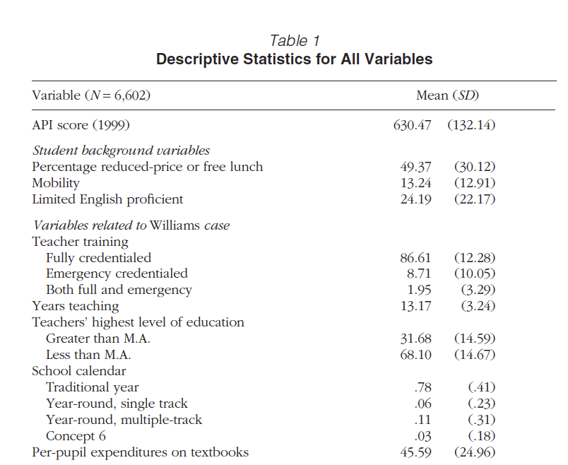

**How to read results (regression models)…**

- The way in which regression results are presented is well standardized across all fields and journals! [some exceptions]
- Regression tables usually show the beta coefficient and standard error (usually in parentheses) for each independent variable
- Columns are individual models
  - Tables usually start with a simple regression model in the first column that only includes the main independent variable(s) of interest: “model 1”
  - Then add control variables incrementally; sometimes done in groupings
  - This allows the author to show the “progression” in the models as variables are added in (particularly important for descriptive research to see changes in model fit statistics)
  - Although, sometimes models in separate columns can also indicate various samples; look at the headings/read the authors description of table
- Read the table notes
  - Provide the key for interpreting the significance levels of p-values as denoted by asterisks ( $*p\le 0.05$, $**p\le 0.01$,$***p\le 0.001$ )
  - Will also tell you what the reference category is for categorical variables!
  - Other useful information
- Table 2: Nested Regression Models Using 1999 API Index as DV, pg. 781
  - The most “standard way” to format regression results
  - You show the “progression” towards your final regression model via multiple models
    - Intercept-only model (no independent variables) [Powers didnt show this]
    - Model 1 can have your independent variable of interest (standard for program eval) or some variables (Powers did student characteristics)
    - Models 2+… shows the addition of control variables
  - Shows beta coefficients, standard errors, and significant levels!

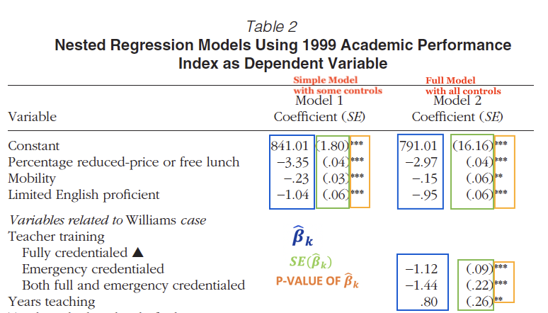

Interpretation for Table 2 for Williams Case Variables

- In text, she hardly interprets beta coefficients beyond “significance and direction”
  - Only sometimes mentions the magnitude of the coefficient
  - This approach is common in “descriptive research”
- Dependent variable, $Y_i$ is “Academic performance index” for school $i$
  - “dependent variable for all analyses is the state constructed API index. This summary score for each school was constructed by weighting student scores in each content area of the SAT-9 test by their national percentile ranking (NPR), and then weighting each content area to create an overall score (California Department of Education Office of Policy and Evaluation, 2000)…”
- **Teacher training** (reference group is fully credentialed teachers)
  - **Emergency Credentialed $\hat{\beta}$ Coefficient: -1.12*** SE= 0.09**
    - Interpretation: “On average, one-percentage-point increase in a school teaching staff’s proportion of emergency credentialed teachers (as opposed to fully credentialed teachers) is associated with a 1.12 point decrease in API score, holding all covariates constant”
- **Teacher Experience**
  - **Years teaching $\hat{\beta}$ Coefficient: .80** SE= 0.26**
    - Interpretation: “A one year increase in a school teaching staff’s average years of experience, on average, is associated with a 0.80 point increase in API score, holding all covariates constant”
- **Teacher Education** (reference group is less than M.A)
  - **Greater than MA $\hat{\beta}$ Coefficient: .42*** SE= 0.06**
    - Interpretation: “On average, a one-percentage-point increase in a school teaching staff’s proportion of teachers with greater than MA degree (as opposed to lower than MA teachers) is associated with a 0.42 point increase in API score, holding all covariates constant”
- **School Calendar** (reference group is traditional year)
  - **Concept 6 $\hat{\beta}$ Coefficient: -34.46*** SE= 4.52**
    - Interpretation: “On average, being a school with a Concept 6 Calendar as opposed to a Traditional Calendar is associated with a 34.46 point decrease in API score, holding all covariates constant”
- **Textbooks**
  - **Per-pupil textbook expenditures $\hat{\beta}$ Coefficient: .11*** SE=0.003**
    - Interpretation: “A $1 increase in per-pupil expenditures for textbooks is associated with a 0.1 point increase in API score, holding all covariates constant”
    - Interpretation: “A $10 increase in per-pupil expenditures for textbooks, on average, is associated with a 1 point increase in API score, holding all covariates constant”
    - Interpretation: “A $100 increase in per-pupil expenditures for textbooks, on average, is associated with a 10 point increase in API score, holding all covariates constant”
- Table 2 shows model fit statistics!
  - Powers is not writing from a program evaluation standpoint
  - Rather she’s trying to show how variables from Williams Case explain (predict!) API scores
  - In this case, measures of model fit are important
  - $R^2$ increases from Model 1 to Model 2
    - Change in $R^2$ doesn’t mean that Williams case IVs add “little” explanation; see pg 782!
  - In text, she mentions overall F-test is significant from Model 1 to Model 2
  - F-test is related to $R^2$
    - $H_0$: model with no independent variables (or limited IVs) fits the data just as well as model with full variables
    - $H_a$: model with more variables fits the data better than model with no IVs

# 4 References